# Test du fonctionnement du service cognitif

Le service coginitif de microsoft Azure est un service qui offre de multiples possibilités, pour notre contexte, qui est la création d'un chatbot avec la fonction polyglotte, le service qui nous intéresse est donc celui du language avec le service **Analyse de texte**.  
Chaque *service* du service cognitif Azure implémente une surcouche API_REST qui permet de communiquer avec celui-ci.

## Sécurisation de la clé

Pour ça on récupère la clé de sécurité stockée dans les variables d'environnement.

```python
import os
# Initialisation de la clé
key_secured = os.environ["COGNITIVE_SERVICE_KEY"]
```

## Préparation de la requête d'envoi au service Azure

On récupère le endpoint du service Azure puis on prépare l'url d'envoi avec Authentification dans le header de la requête.

```python
import requests, uuid, json

subscription_key = key_secured
# Le endpoint doit correspondre si l'emplacement choisi lors de la création est "Global"
endpoint = os.environ["COGNITIVE_SERVICE_ENDPOINT"]
# pour la fonction polyglotte nous avons besoin de detecter la langue d'envoi
# pour ça on fait appel a la fonction "/detect" de l'API
path = '/text/analytics/v3.0/languages'

constructed_url = endpoint + path

# Authentification
headers = {
    'Ocp-Apim-Subscription-Key': subscription_key,
    'Content-type': 'application/json',
    'X-ClientTraceId': str(uuid.uuid4())
}
```

## Préparation du texte à envoyer ( test avec 5 langues )

Ce test est fait sur 5 langues choisies par mes soins.  
Il s'agit du même texte, traduit de 5 façons différentes.

```python
sendRequest = {
    "documents": [
        {
            'id':1,
            'text': 'Hello my name is Sébastien TUCCIO.' # Anglais
        },{
            'id':2,
            'text': 'Bonjour, je m\'appel Sébastien TUCCIO.' # Français
        },{
            'id':3,
            'text': 'Ciao mi chiamo Sébastien TUCCIO' # Italien
        },{
            'id':4,
            'text': 'Hola, me llamo Sébastien TUCCIO.' # Espagnol
        },{
            'id':5,
            'text': 'Hallo, mein Name ist Sébastien TUCCIO.' # Allemand
        }
    ]
}
```

## Envoi et analyse du retour de la requête (json)

```python
#Envoi de la requête a l'API du service cognitive Azure
request = requests.post(constructed_url, headers=headers, json=sendRequest)

# Récupération des données
response = request.json()

# Affichage
print(json.dumps(response, sort_keys=True, ensure_ascii=False, indent=4, separators=(',', ': ')))
```

```
{
    "documents": [
        {
            "detectedLanguage": {
                "confidenceScore": 0.54,
                "iso6391Name": "en",
                "name": "English"
            },
            "id": "1",
            "warnings": []
        },
        {
            "detectedLanguage": {
                "confidenceScore": 0.71,
                "iso6391Name": "fr",
                "name": "French"
            },
            "id": "2",
            "warnings": []
        },
        {
            "detectedLanguage": {
                "confidenceScore": 0.97,
                "iso6391Name": "it",
                "name": "Italian"
            },
            "id": "3",
            "warnings": []
        },
        {
            "detectedLanguage": {
                "confidenceScore": 0.76,
                "iso6391Name": "es",
                "name": "Spanish"
            },
            "id": "4",
            "warnings": []
        },
        {
            "detectedLanguage": {
                "confidenceScore": 0.78,
                "iso6391Name": "de",
                "name": "German"
            },
            "id": "5",
            "warnings": []
        }
    ],
    "errors": [],
    "modelVersion": "2021-01-05"
}
```

Le texte envoyé a été dans l'ensemble correctement identifié.  
On remarque 4 éléments clés sur le retour de la requête :

1. "id" correspond a l'ID du document envoyé
2. "name" correspond à la langue en anglais
3. "iso6391Name" correspond a l'identification de la langue par son acronyme ISO 639-1 "fr" pour "French" par exemple. [Acronyme à retrouver ici.](https://docs.microsoft.com/fr-fr/azure/cognitive-services/text-analytics/language-support?tabs=language-detection)
4. "confidenceScore" correspond à la confiance du résultat. avec 0 qui est un score faible et 1 un indice de confiance élevé

# Récupération et Analyse du jeu de données

Dans cette partie nous allons récupérer puis faire une analyse rapide du jeu de données.

## Récupération du DataFrame

```python
import pandas as pd
import numpy as np

# récupération du jeu de données dans "x_test.txt"
dfx = pd.read_csv("./data/x_test.txt",header=None,delimiter="\r\n",encoding="utf-8",engine="python",names=['text'])
# Ajout dans une nouvelle columns "label" qui correspond au label du fichier label.csv que nous allons implémenter par la suite
dfx["label"] = pd.read_csv("./data/y_test.txt",header=None,delimiter="\r\n",encoding="utf-8",engine="python")

print("Dimensionnalité de la DataFrame: ", dfx.shape)
dfx
```

```
Dimensionnalité de la DataFrame:  (117500, 2)
```

|  | text | label |
| --- | --- | --- |
| 0 | Ne l fin de l seclo XIX l Japon era inda çconh... | mwl |
| 1 | Schiedam is gelegen tussen Rotterdam en Vlaard... | nld |
| 2 | ГIурусаз батальонал, гьоркьор гIарадабиги лъун... | ava |
| 3 | ರಾಜ್ಯಶಾಸ್ತ್ರದ ಪಿತಾಮಹೆ ಅರಿಸ್ಟಾಟಲ್. ರಾಜ್ಯಶಾಸ್ತ್ರ... | tcy |
| 4 | Halukum adalah kelenjar tiroid nang menonjol d... | bjn |
| ... | ... | ... |
| 117495 | Wakati wa mimba,homa ya Q ni vigumu kutibu kwa... | swa |
| 117496 | گیلون یک ته تاریخی منطقه‌ سفیدرود دلتای طرف ای... | glk |
| 117497 | តាមរយៈការចិញ្ចឹមមនោសញ្ចេតនាជាតិនិយមបែបន... | khm |
| 117498 | روس اک وفاق اے تے 1 مارچ 2008ء توں اسدیاں 83 و... | pnb |
| 117499 | Chute annaée-lo, la Normaundie n'est pus recou... | nrm |

117500 rows × 2 columns

Nous avons maintenant une data frame de 117.500 lignes avec le texte et le label associés.  
Le label est le "Code pour la représentration des noms de langue" = **ISO369-3**.  
Cet indicateur va nous permettre de merge **"label"** avec **"ISO 369-3"** du fichier label.  
Le **Wiki Code** du fichier Label permettra de connaître la langue lors de la détection avec Azure car c'est celui qui se rapporche le plus du format final (que nous retourne le service).

## Récupération du fichier Label

```python
# Récupération du fichier label
lab = pd.read_csv("./data/labels.csv",sep=";",encoding="utf-8")
# On ne conserve que les columns qui peuvent nous intéresser
lab= lab.drop(columns=["Writing system","German","Remarks","Synonyms","Language family"])
# On nettoie le jeu de données des valeurs nulles
lab=lab.dropna(how="any")


print("Dimensionnalité de la DataFrame: ", lab.shape)
lab.head()
```

```
Dimensionnalité de la DataFrame:  (231, 4)
```

|  | Label | English | Wiki Code | ISO 369-3 |
| --- | --- | --- | --- | --- |
| 0 | ace | Achinese | ace | ace |
| 1 | afr | Afrikaans | af | afr |
| 2 | als | Alemannic German | als | gsw |
| 3 | amh | Amharic | am | amh |
| 4 | ang | Old English | ang | ang |

Après récupération et nettoyage du fichier nous avons 231 **Label** et **ISO 369-3** associés.

# Prépration du jeu de données

Nous avons déjà nettoyé le jeu de données et préparé une partie du jeu de données.  
Il nous reste 2 informations à combiner :

1. Le dataframe contenant tous les paragraphes et les labels associés
2. le fichier de label qui lui associe le label et l'ISO 639-1 (Wiki Code)

```python
# Utilisation de l'algèbre relationnelle (jointure gauche par l'index "Label" et "ISO 369-3")
df_merge = dfx.merge(lab,left_on="label",right_on="ISO 369-3",how="left")
# Suppression des columns inutile pour la suite
df_merge= df_merge.drop(columns=["ISO 369-3","Label","label"])
df_merge=df_merge.rename(columns={"Wiki Code":"lang_iso_639-1"})
df_merge["id"]=df_merge.index
df_merge
```

|  | text | English | lang_iso_639-1 | id |
| --- | --- | --- | --- | --- |
| 0 | Ne l fin de l seclo XIX l Japon era inda çconh... | Mirandese | mwl | 0 |
| 1 | Schiedam is gelegen tussen Rotterdam en Vlaard... | Dutch | nl | 1 |
| 2 | ГIурусаз батальонал, гьоркьор гIарадабиги лъун... | Avar | av | 2 |
| 3 | ರಾಜ್ಯಶಾಸ್ತ್ರದ ಪಿತಾಮಹೆ ಅರಿಸ್ಟಾಟಲ್. ರಾಜ್ಯಶಾಸ್ತ್ರ... | Tulu | tcy | 3 |
| 4 | Halukum adalah kelenjar tiroid nang menonjol d... | Banjar | bjn | 4 |
| ... | ... | ... | ... | ... |
| 117995 | Wakati wa mimba,homa ya Q ni vigumu kutibu kwa... | Swahili (macrolanguage) | sw | 117995 |
| 117996 | گیلون یک ته تاریخی منطقه‌ سفیدرود دلتای طرف ای... | Gilaki | glk | 117996 |
| 117997 | តាមរយៈការចិញ្ចឹមមនោសញ្ចេតនាជាតិនិយមបែបន... | Central Khmer | km | 117997 |
| 117998 | روس اک وفاق اے تے 1 مارچ 2008ء توں اسدیاں 83 و... | Western Panjabi | pnb | 117998 |
| 117999 | Chute annaée-lo, la Normaundie n'est pus recou... | Narom | nrm | 117999 |

118000 rows × 4 columns

Le jeu de données comprends maintenant :

1. le paragraphe
2. l'ISO 639-1
3. la langue en Anglais (optionnel, gardée pour plus de compréhension)

## Répartition du dataset

```python
count = df_merge[["lang_iso_639-1","English"]].value_counts()

count.describe()
```

```
count    230.0
mean     500.0
std        0.0
min      500.0
25%      500.0
50%      500.0
75%      500.0
max      500.0
dtype: float64
```

On constate que sur toutes les langues il y a 500 paragraphes exactement.

# Sélection des 5 langues les plus parlées

Dans cette partie nous allons sélectionner les 5 langues les plus parlées dans le monde afin de faire un test du service cognitive sur sa fiabilité à donner le bon résultat.  
Les 5 langues les plus parlées dans le monde sont dans l'ordre :

1. Chinese
2. Spanish
3. English
4. Hindi
5. Arabic

Source : [babbel.com](https://www.babbel.com/en/magazine/the-10-most-spoken-languages-in-the-world)

## Récupération des labels des langues les plus parlées depuis le dataframe Label

```python
# On recupère les 5 ISO 639-1 des 5 langues les plus parlées dans le monde
five_langue = ['zh', 'es','en','hi','ar']
# Pour retrouver la forme ISO 639-1(Wiki Code) on peut utiliser cette ligne :
Langue_to_test = 'Standard Chinese'
print("la reférence en ISO 639-1 pour la langue \"",
      Langue_to_test,
      "\" (en Anglais) est: ",
      lab.loc[lab['English'] == Langue_to_test]["Wiki Code"].values[0])
```

```
la reférence en ISO 639-1 pour la langue " Standard Chinese " (en Anglais) est:  zh
```

## Création du dataset d'envoie des données

```python
test = df_merge[df_merge["lang_iso_639-1"].isin(five_langue)]
test
```

|  | text | English | lang_iso_639-1 | id |
| --- | --- | --- | --- | --- |
| 15 | كانت رحلة كوك - فولسوم - بيترسون الاستكشافية ع... | Arabic | ar | 15 |
| 42 | 大都会区有它自己的当地路边快餐口味，包括瓦达帕夫（蓬松面包劈开一半，填入锅贴）、潘尼普里（油... | Standard Chinese | zh | 42 |
| 50 | La ciudad de San Cristóbal es sede del Hospita... | Spanish | es | 50 |
| 68 | Anton (or Antonius) Maria Schyrleus (also Schy... | English | en | 68 |
| 113 | बांग्लादेश के मुख्य न्यायाधीश का पद, बांग्लादे... | Hindi | hi | 113 |
| ... | ... | ... | ... | ... |
| 117696 | Fue fundado el 18 de octubre de 1963. El día 2... | Spanish | es | 117696 |
| 117775 | 戈尔巴乔夫结束了苏共的专制和暴政，使人民获得了民主、法治和自由，并使得东欧国家自主发展，结束... | Standard Chinese | zh | 117775 |
| 117779 | El investigador ha recibido varios reconocimie... | Spanish | es | 117779 |
| 117964 | Con motivo de la celebración del Septuagésimoq... | Spanish | es | 117964 |
| 117971 | 1999年10月，當時還只有16歲的她在美國出道，以Mai-K名義推出首張英文《Baby I... | Standard Chinese | zh | 117971 |

2500 rows × 4 columns

La création du dataset est terminée, nous avons un dataset comprenant les paragraphes et l'ISO639-1 pour les 5 langues choisies.

# Envoi du dataset au service cognitif Azure

> Pour plus de clarté, je réécrie certaine partie de code faite dans la partie test du service cognitif

Dans l'ensemble le code d'envoie est similaire au premier utilisé.  
J'utiliserai ici les librairies Azure, les 2 fonctionnements peuvent être utilisés.

```python
from azure.core.credentials import AzureKeyCredential
from azure.ai.textanalytics import TextAnalyticsClient

key = os.environ["COGNITIVE_SERVICE_KEY"]

endpoint = os.environ["COGNITIVE_SERVICE_ENDPOINT"]
```

```python
# Authentification
def authenticate_client():
    ta_credential = AzureKeyCredential(key)
    text_analytics_client = TextAnalyticsClient(
            endpoint=endpoint,
            credential=ta_credential)
    return text_analytics_client

client = authenticate_client()
```

```python
# Création de la méthode de détection du language d'un document
def language_detection(client,documents):
    try:
        response = client.detect_language(documents = documents, country_hint = 'us')
        return response

    except Exception as err:
        print("Encountered exception. {}".format(err))
```

## Nombre de textes pour notre échantillon

```python
# Le maximum est de 500 par langue (nombre de paragraphes par langue)
nb_text = 100
```

Le service cognitif Azure est maintenant prêt à être utilisé. Pour ce faire nous allons créer un échantillon de données pour récupérer le nombre de texte dans chaque langue définit au dessus dans la variable `nb_text`.

## Transformation en document pour l'envoie au service Azure

```python
# Cette ligne permet de sélectionner seulement les n premier ligne pour chaque lang iso choisi
# Et également de les formater au format "record" => "key"=> "value"
sample_test = test.groupby('lang_iso_639-1').head(nb_text).to_dict("records")
print("La taille de l'échantillon est de: ",len(sample_test))
print("Format d'un échantillon: ",sample_test[0])
```

```
La taille de l'échantillon est de:  500
Format d'un échantillon:  {'text': 'كانت رحلة كوك - فولسوم - بيترسون الاستكشافية عام 1869م أول رحلة استكشافية مفصلة إلى منطقة يلوستون، وضمت الرحلة ثلاثة مستكشفين ممّولين من قِبَل القطاع الخاص وقد تبع فريق فولسوم نهر يلوستون إلى بحيرة يلوستون وقد احتفظ الأعضاء بمجلة واعتمدوا على المعلومات الواردة فيه…
```

```python
# résultat contenant tous les documents
result = language_detection(client,sample_test)
```

# Analyse des résultats

Maintenant que nous avons les résultats il faut les implémenter et les comparer pour voir la véracité des informations retournées.

## Préparation du jeu de données pour l'analyse

```python
mapResult = {}
for doc in result:
#     print("Language detected: {}".format(doc.primary_language.name))
#     print("ISO6391 name: {}".format(doc.primary_language.iso6391_name))
#     print("Confidence score: {}".format(doc.primary_language.confidence_score))
#     print("ID document: {}\n".format(doc.id))
    mapResult[int(doc.id)]={
        "lang_iso":doc.primary_language.iso6391_name,
        "score":doc.primary_language.confidence_score
    }
```

```python
# Ajout de 2 columns "score" et "detect_lang" qui sont les résultats de la requête azure
for i in range(len(sample_test)):
    sample_test[i]["score"]=mapResult[sample_test[i]["id"]]["score"]
    # iso 639-1 ne prend que 2 caractères, il faut donc prendre que les 2 premiers caractères.
    sample_test[i]["detect_lang"]=mapResult[sample_test[i]["id"]]["lang_iso"][:2]
```

## Comparatif attendu/obtenu

```python
# Transformation dictionnaire en dataframe
sample_test = pd.DataFrame.from_dict(sample_test)
# Analyse de l'estimation avec 1 comme resultat positif et 0 négatif
sample_test["good_detection"] = (sample_test["lang_iso_639-1"] == sample_test["detect_lang"]).astype(int)

sample_test
```

|  | text | English | lang_iso_639-1 | id | score | detect_lang | good_detection |
| --- | --- | --- | --- | --- | --- | --- | --- |
| 0 | كانت رحلة كوك - فولسوم - بيترسون الاستكشافية ع... | Arabic | ar | 15 | 1.00 | ar | 1 |
| 1 | 大都会区有它自己的当地路边快餐口味，包括瓦达帕夫（蓬松面包劈开一半，填入锅贴）、潘尼普里（油... | Standard Chinese | zh | 42 | 0.99 | zh | 1 |
| 2 | La ciudad de San Cristóbal es sede del Hospita... | Spanish | es | 50 | 0.83 | es | 1 |
| 3 | Anton (or Antonius) Maria Schyrleus (also Schy... | English | en | 68 | 0.98 | en | 1 |
| 4 | बांग्लादेश के मुख्य न्यायाधीश का पद, बांग्लादे... | Hindi | hi | 113 | 1.00 | hi | 1 |
| ... | ... | ... | ... | ... | ... | ... | ... |
| 495 | Mientras Gaff protege la entrada a la casa de ... | Spanish | es | 28521 | 0.99 | es | 1 |
| 496 | Lucé-sous-Ballon es una población y comuna fra... | Spanish | es | 28554 | 0.98 | es | 1 |
| 497 | Yadagiri, P. 1988. A new sauropod Kotasaurus y... | Spanish | es | 28560 | 0.90 | en | 0 |
| 498 | El Cabildo de San Isidoro recibe al Ayuntamien... | Spanish | es | 28579 | 0.99 | es | 1 |
| 499 | En 1971, grabó Mamy Blue que rompió las listas... | Spanish | es | 28590 | 0.90 | es | 1 |

500 rows × 7 columns

## Résultat global

```python
analyse_good_detection = sample_test.pivot_table("good_detection",index="English",aggfunc="sum")
analyse_mean_score = sample_test.pivot_table("score",index="English",aggfunc="mean")

analyse = pd.merge(analyse_good_detection,analyse_mean_score,on="English")

analyse["sample_size"]=nb_text

analyse["success_rate"]=(analyse.good_detection/analyse.sample_size)*100.0
analyse["error_rate"] = 100-analyse["success_rate"]

analyse= analyse.rename(columns={"score":"score_mean"})
analyse = analyse.rename_axis(None)

analyse
```

|  | good_detection | score_mean | sample_size | success_rate | error_rate |
| --- | --- | --- | --- | --- | --- |
| Arabic | 100 | 1.0000 | 100 | 100.0 | 0.0 |
| English | 100 | 0.9746 | 100 | 100.0 | 0.0 |
| Hindi | 100 | 0.9985 | 100 | 100.0 | 0.0 |
| Spanish | 98 | 0.9709 | 100 | 98.0 | 2.0 |
| Standard Chinese | 100 | 0.9854 | 100 | 100.0 | 0.0 |

## Analyse des résultats en echec

```python
# Pour afficher tout le texte de la ligne
pd.options.display.max_rows
pd.set_option('display.max_colwidth', 0)
# On ne récupère que les "mauvaises" détections
sample_test.loc[sample_test.good_detection==0][["text","score","lang_iso_639-1","detect_lang"]]
```

|  | text | score | lang_iso_639-1 | detect_lang |
| --- | --- | --- | --- | --- |
| 479 | Bandyopadhyay, S. & RoyChowdhury, K. 1996. Beginning of the Continental Jurassic in India: A Paleontological Approach. Museum of Northern Arizona Bulletin. The Continental Jurassic. Transactions of th… | 0.79 | es | en |
| 497 | Yadagiri, P. 1988. A new sauropod Kotasaurus yamanpalliensis from Lower Jurassic Kota Formation of India. Records of the Geological Survey of India, 11, 102-127. | 0.90 | es | en |

On remarque que les textes qui ont été detectés comme mauvaise identification de la langue sont écrits principalement dans la langue detecté car se sont **des noms de livres ou de personnes certainement Anglophone**.

# Représentation graphique des résultats

Pour mieux visualiser ces résultats, nous allons les afficher sous forme de graphique.

> "Un bon croquis vaut mieux qu'un long discours."

## Graphique

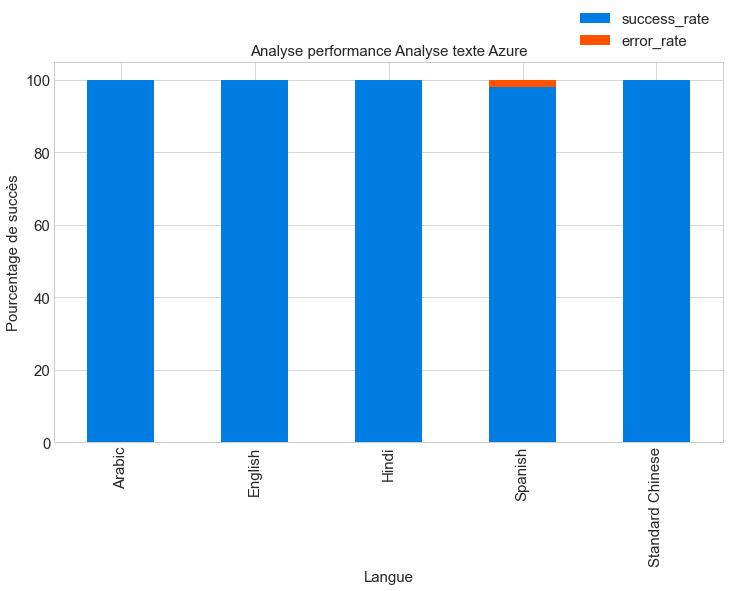

```python
#Affichage du graphique
visualisation()
```

# Conclusion

Les résultats du service Cognitif Azure **Analyse de texte** sont très positifs.  
Le taux de réussite est de 100% si on ommet les 2 résultats sur 500 qui ont été induit par des noms propres d'auteurs ou de titres de livres certainement Anglophone.